# Predictive Analysis on Stroke Patient

The Stroke Predictor Tool

Jenifer Mayang Jues (S2016572) - Team Leader, Moses Wong Cheng Qing (S2134986), Shalini Gunalan (S2147287), Tham Foo Soon (17090535), Radziah Zainuddin (S2156690)

# Problem Statement and Questions

**Problem**

According to the World Health Organization (WHO) stroke is the 2nd leading cause of death globally, responsible for approximately 11% of total deaths. Early detection of stroke using prediction model can allow medical officers to provide immediate or efficient treatment that may minimize the long-term effects of a stroke and even prevent death.

**Questions**

1. Which factors are important in predicting stroke?
2. Which is the best sampling method for imbalanced data?
3. Which is the best classification model (logistic regression or random forest) for stroke prediction?

# Methodology (CRISP-DM)

[figure not shown]

# Data Story and Visualization

## Visualization

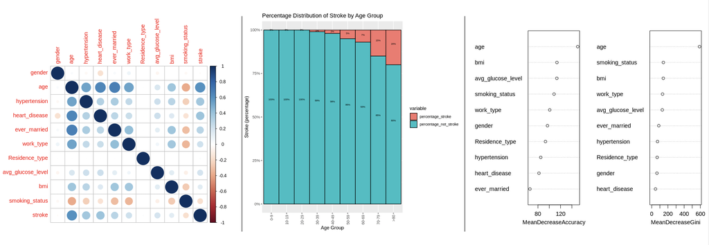

# Application

## Code

Reproducibility:

- Codes and data are published publicly in github - [The Stroke Github](https://github.com/jenifermjues/the-stroke-project) *(right click)*
- Stroke prediction app is published on rpubs.
- The dataset used are publicly available.

## Shiny Apps

Click on the image to direct you to the apps.

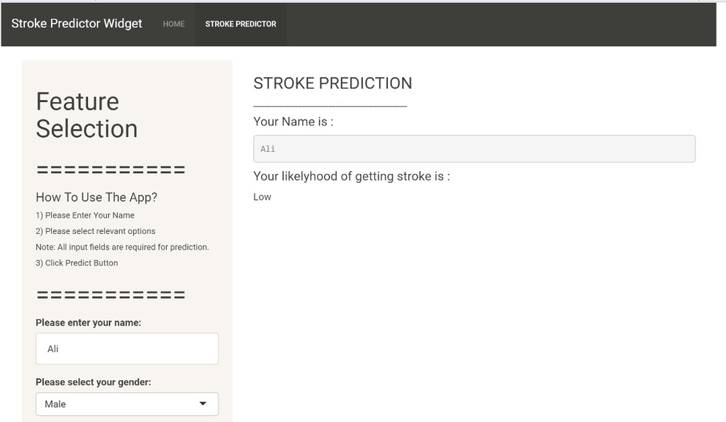